**Google Data Analytics Certificate - Cyclistic Marketing Report**

**1. Introduction**

The following report is the final case study project for the Google Data Analytics Professional Certificate Case Study. In this case study we will be analyzing data from a bike sharing company named Cyclistic. Our analysis will be carried out following the steps of the data analysis process: ask, prepare, process, analyze, share and act.

Ciclistic is a bike share program that features more than 5,800 bicycles and 600 docking stations around the Chicago area. The goal of this project is to analyze the company data and to provide our three main recommendations to the Cyclistic marketing analytics team in order to transform casual users into annual suscribers.

**2. Ask**

Statement of business task: Thinking of marketing strategies in order to convert the casual users into annual suscribers. Key stakeholders: Lily Moreno (Marketing Director) and Cyclistic Marketing Analytics Team

**3. Prepare**

The source of our data is an internal dataset provided by Cyclistic (Divvy) with one dataset per month. We will analyze the last 12 month period of available data at the time of this analysis that goes from August 2022 to July 2023. The data is organized in csv files with one file per month. The datasets provide information on each trip done by users of cyclistic. Information contained covers aspects such as trip duration, user type, bike type, docking station, among other data.

All the data complies with the ROCCC method and is valid for our analysis. Our data is reliable and comes from a trusted source. It is original. It is comprehensive since it provides enough data to obtain relevant insights. Data is current as well, since we have data sets for the previous 12 months. Our data is also cited and under a license.

**4. Process**

**4.1 Installing and loading packages needed for our analysis**

```r
install.packages("readr")
install.packages("ggplot2")
install.packages("dplyr")
install.packages("sqldf")
install.packages("janitor")
install.packages("lubridate")
install.packages("skimr")
install.packages("DBI")
install.packages("odbc")
install.packages("tidyverse")
install.packages('magrittr')
```

**4.2 Loading monthly CSV datasets**

```r
aug <- read.csv("C:\\Users\\Gebruiker\\OneDrive\\Escritorio\\Data Analytics Projects\\Google Certification\\csvfiles\\202208-divvy-tripdata.csv")
sep <- read.csv("C:\\Users\\Gebruiker\\OneDrive\\Escritorio\\Data Analytics Projects\\Google Certification\\csvfiles\\202209-divvy-publictripdata.csv")
oct <- read.csv("C:\\Users\\Gebruiker\\OneDrive\\Escritorio\\Data Analytics Projects\\Google Certification\\csvfiles\\202210-divvy-tripdata.csv")
nov <- read.csv("C:\\Users\\Gebruiker\\OneDrive\\Escritorio\\Data Analytics Projects\\Google Certification\\csvfiles\\202211-divvy-tripdata.csv")
dec <- read.csv("C:\\Users\\Gebruiker\\OneDrive\\Escritorio\\Data Analytics Projects\\Google Certification\\csvfiles\\202212-divvy-tripdata.csv")
jan <- read.csv("C:\\Users\\Gebruiker\\OneDrive\\Escritorio\\Data Analytics Projects\\Google Certification\\csvfiles\\202301-divvy-tripdata.csv")
feb <- read.csv("C:\\Users\\Gebruiker\\OneDrive\\Escritorio\\Data Analytics Projects\\Google Certification\\csvfiles\\202302-divvy-tripdata.csv")
mar <- read.csv("C:\\Users\\Gebruiker\\OneDrive\\Escritorio\\Data Analytics Projects\\Google Certification\\csvfiles\\202303-divvy-tripdata.csv")
apr <- read.csv("C:\\Users\\Gebruiker\\OneDrive\\Escritorio\\Data Analytics Projects\\Google Certification\\csvfiles\\202304-divvy-tripdata.csv")
may <- read.csv("C:\\Users\\Gebruiker\\OneDrive\\Escritorio\\Data Analytics Projects\\Google Certification\\csvfiles\\202305-divvy-tripdata.csv")
jun <- read.csv("C:\\Users\\Gebruiker\\OneDrive\\Escritorio\\Data Analytics Projects\\Google Certification\\csvfiles\\202306-divvy-tripdata.csv")
jul <- read.csv("C:\\Users\\Gebruiker\\OneDrive\\Escritorio\\Data Analytics Projects\\Google Certification\\csvfiles\\202307-divvy-tripdata.csv")
```

**4.3 Overview of the data sets**

We will start our analysis by doing a quick overview of each data set in order to check that they are consistent.

```r
head(aug,5)
```

```
##            ride_id rideable_type     started_at       ended_at
## 1 550CF7EFEAE0C618 electric_bike 8/7/2022 21:34 8/7/2022 21:41
## 2 DAD198F405F9C5F5 electric_bike 8/8/2022 14:39 8/8/2022 14:53
## 3 E6F2BC47B65CB7FD electric_bike 8/8/2022 15:29 8/8/2022 15:40
## 4 F597830181C2E13C electric_bike  8/8/2022 2:43  8/8/2022 2:58
## 5 0CE689BB4E313E8D electric_bike 8/7/2022 20:24 8/7/2022 20:29
##   start_station_name start_station_id end_station_name end_station_id start_lat
## 1                                                                         41.93
## 2                                                                         41.89
## 3                                                                         41.97
## 4                                                                         41.94
## 5                                                                         41.85
##   start_lng end_lat end_lng member_casual
## 1    -87.69   41.94  -87.72        casual
## 2    -87.64   41.92  -87.64        casual
## 3    -87.69   41.97  -87.66        casual
## 4    -87.65   41.97  -87.69        casual
## 5    -87.65   41.84  -87.66        casual
```

```r
head(sep,5)
```

```
##            ride_id rideable_type     started_at       ended_at
## 1 5156990AC19CA285 electric_bike  9/1/2022 8:36  9/1/2022 8:39
## 2 E12D4A16BF51C274 electric_bike 9/1/2022 17:11 9/1/2022 17:14
## 3 A02B53CD7DB72DD7 electric_bike 9/1/2022 17:15 9/1/2022 17:16
## 4 C82E05FEE872DF11 electric_bike  9/1/2022 9:00  9/1/2022 9:10
## 5 4DEEB4550A266AE1 electric_bike  9/1/2022 7:30  9/1/2022 7:32
##   start_station_name start_station_id               end_station_name
## 1                                     California Ave & Milwaukee Ave
## 2
## 3
## 4
## 5
##   end_station_id start_lat start_lng  end_lat   end_lng member_casual
## 1          13084     41.93    -87.69 41.92269 -87.69715        casual
## 2                    41.87    -87.62 41.87000 -87.62000        casual
## 3                    41.87    -87.62 41.87000 -87.62000        casual
## 4                    41.93    -87.69 41.94000 -87.67000        casual
## 5                    41.92    -87.73 41.92000 -87.73000        casual
```

```r
head(oct,5)
```

```
##            ride_id rideable_type       started_at         ended_at
## 1 A50255C1E17942AB  classic_bike 10/14/2022 17:13 10/14/2022 17:19
## 2 DB692A70BD2DD4E3 electric_bike  10/1/2022 16:29  10/1/2022 16:49
## 3 3C02727AAF60F873 electric_bike 10/19/2022 18:55 10/19/2022 19:03
## 4 47E653FDC2D99236 electric_bike  10/31/2022 7:52  10/31/2022 7:58
## 5 8B5407BE535159BF  classic_bike 10/13/2022 18:41 10/13/2022 19:26
##          start_station_name start_station_id
## 1  Noble St & Milwaukee Ave            13290
## 2 Damen Ave & Charleston St            13288
## 3  Hoyne Ave & Balmoral Ave              655
## 4        Rush St & Cedar St     KA1504000133
## 5         900 W Harrison St            13028
##                       end_station_name end_station_id start_lat start_lng
## 1            Larrabee St & Division St   KA1504000079  41.90068 -87.66260
## 2             Damen Ave & Cullerton St          13089  41.92004 -87.67794
## 3             Western Ave & Leland Ave   TA1307000140  41.97988 -87.68190
## 4 Orleans St & Chestnut St (NEXT Apts)            620  41.90227 -87.62769
## 5                    Adler Planetarium          13431  41.87475 -87.64981
##    end_lat   end_lng member_casual
## 1 41.90349 -87.64335        member
## 2 41.85497 -87.67570        casual
## 3 41.96640 -87.68870        member
## 4 41.89820 -87.63754        member
## 5 41.86610 -87.60727        casual
```

```r
head(nov,5)
```

```
##            ride_id rideable_type       started_at         ended_at
## 1 BCC66FC6FAB27CC7 electric_bike  11/10/2022 6:21  11/10/2022 6:31
## 2 772AB67E902C180F  classic_bike   11/4/2022 7:31   11/4/2022 7:46
## 3 585EAD07FDEC0152  classic_bike 11/21/2022 17:20 11/21/2022 17:34
## 4 91C4E7ED3C262FF9  classic_bike 11/25/2022 17:29 11/25/2022 17:45
## 5 709206A3104CABC8  classic_bike 11/29/2022 17:24 11/29/2022 17:42
##           start_station_name start_station_id       end_station_name
## 1        Canal St & Adams St            13011 St. Clair St & Erie St
## 2        Canal St & Adams St            13011 St. Clair St & Erie St
## 3 Indiana Ave & Roosevelt Rd           SL-005 St. Clair St & Erie St
## 4 Indiana Ave & Roosevelt Rd           SL-005 St. Clair St & Erie St
## 5 Indiana Ave & Roosevelt Rd           SL-005 St. Clair St & Erie St
##   end_station_id start_lat start_lng  end_lat  end_lng member_casual
## 1          13016  41.87940 -87.63985 41.89435 -87.6228        member
## 2          13016  41.87926 -87.63990 41.89435 -87.6228        member
## 3          13016  41.86789 -87.62304 41.89435 -87.6228        member
## 4          13016  41.86789 -87.62304 41.89435 -87.6228        member
## 5          13016  41.86789 -87.62304 41.89435 -87.6228        member
```

```r
head(dec,5)
```

```
##            ride_id rideable_type       started_at         ended_at
## 1 65DBD2F447EC51C2 electric_bike  12/5/2022 10:47  12/5/2022 10:56
## 2 0C201AA7EA0EA1AD  classic_bike  12/18/2022 6:42  12/18/2022 7:08
## 3 E0B148CCB358A49D electric_bike  12/13/2022 8:47  12/13/2022 8:59
## 4 54C5775D2B7C9188  classic_bike 12/13/2022 18:50 12/13/2022 19:19
## 5 A4891F78776D35DF  classic_bike 12/14/2022 16:13 12/14/2022 16:27
##           start_station_name start_station_id          end_station_name
## 1 Clifton Ave & Armitage Ave     TA1307000163 Sedgwick St & Webster Ave
## 2     Broadway & Belmont Ave            13277 Sedgwick St & Webster Ave
## 3      Sangamon St & Lake St     TA1306000015    St. Clair St & Erie St
## 4      Shields Ave & 31st St     KA1503000038    Damen Ave & Madison St
## 5  Ashland Ave & Chicago Ave            13247 Damen Ave & Charleston St
##   end_station_id start_lat start_lng  end_lat   end_lng member_casual
## 1          13191  41.91824 -87.65711 41.92217 -87.63889        member
## 2          13191  41.94011 -87.64545 41.92217 -87.63889        casual
## 3          13016  41.88592 -87.65113 41.89435 -87.62280        member
## 4          13134  41.83846 -87.63541 41.88137 -87.67493        member
## 5          13288  41.89595 -87.66773 41.92008 -87.67785        casual
```

```r
head(jan,5)
```

```
##            ride_id rideable_type      started_at        ended_at
## 1 F96D5A74A3E41399 electric_bike 1/21/2023 20:05 1/21/2023 20:16
## 2 13CB7EB698CEDB88  classic_bike 1/10/2023 15:37 1/10/2023 15:46
## 3 BD88A2E670661CE5 electric_bike   1/2/2023 7:51   1/2/2023 8:05
## 4 C90792D034FED968  classic_bike 1/22/2023 10:52 1/22/2023 11:01
## 5 3397017529188E8A  classic_bike 1/12/2023 13:58 1/12/2023 14:13
##            start_station_name start_station_id               end_station_name
## 1 Lincoln Ave & Fullerton Ave     TA1309000058      Hampden Ct & Diversey Ave
## 2       Kimbark Ave & 53rd St     TA1309000037        Greenwood Ave & 47th St
## 3      Western Ave & Lunt Ave           RP-005 Valli Produce - Evanston Plaza
## 4       Kimbark Ave & 53rd St     TA1309000037        Greenwood Ave & 47th St
## 5       Kimbark Ave & 53rd St     TA1309000037        Greenwood Ave & 47th St
##   end_station_id start_lat start_lng  end_lat   end_lng member_casual
## 1         202480  41.92407 -87.64628 41.93000 -87.64000        member
## 2   TA1308000002  41.79957 -87.59475 41.80983 -87.59938        member
## 3            599  42.00857 -87.69048 42.03974 -87.69941        casual
## 4   TA1308000002  41.79957 -87.59475 41.80983 -87.59938        member
## 5   TA1308000002  41.79957 -87.59475 41.80983 -87.59938        member
```

```r
head(feb,5)
```

```
##            ride_id rideable_type      started_at        ended_at
## 1 CBCD0D7777F0E45F  classic_bike 2/14/2023 11:59 2/14/2023 12:13
## 2 F3EC5FCE5FF39DE9 electric_bike 2/15/2023 13:53 2/15/2023 13:59
## 3 E54C1F27FA9354FF  classic_bike 2/19/2023 11:10 2/19/2023 11:35
## 4 3D561E04F739CC45 electric_bike 2/26/2023 16:12 2/26/2023 16:39
## 5 0CB4B4D53B2DBE05 electric_bike 2/20/2023 11:55 2/20/2023 12:05
##             start_station_name start_station_id              end_station_name
## 1 Southport Ave & Clybourn Ave     TA1309000030        Clark St & Schiller St
## 2   Clarendon Ave & Gordon Ter            13379    Sheridan Rd & Lawrence Ave
## 3 Southport Ave & Clybourn Ave     TA1309000030       Aberdeen St & Monroe St
## 4 Southport Ave & Clybourn Ave     TA1309000030 Franklin St & Adams St (Temp)
## 5  Prairie Ave & Garfield Blvd     TA1307000160   Cottage Grove Ave & 63rd St
##   end_station_id start_lat start_lng  end_lat   end_lng member_casual
## 1   TA1309000024  41.92077 -87.66371 41.90799 -87.63150        casual
## 2   TA1309000041  41.95788 -87.64958 41.96952 -87.65469        casual
## 3          13156  41.92077 -87.66371 41.88042 -87.65552        member
## 4   TA1309000008  41.92087 -87.66373 41.87943 -87.63550        member
## 5   KA1503000054  41.79483 -87.61879 41.78053 -87.60597        member
```

```r
head(mar,5)
```

```
##            ride_id rideable_type      started_at        ended_at
## 1 6842AA605EE9FBB3 electric_bike  3/16/2023 8:20  3/16/2023 8:22
## 2 F984267A75B99A8C electric_bike  3/4/2023 14:07  3/4/2023 14:15
## 3 FF7CF57CFE026D02  classic_bike 3/31/2023 12:28 3/31/2023 12:38
## 4 6B61B916032CB6D6  classic_bike 3/22/2023 14:09 3/22/2023 14:24
## 5 E55E61A5F1260040 electric_bike   3/9/2023 7:15   3/9/2023 7:26
##                     start_station_name start_station_id
## 1              Clark St & Armitage Ave            13146
## 2 Public Rack - Kedzie Ave & Argyle St              491
## 3 Orleans St & Chestnut St (NEXT Apts)              620
## 4            Desplaines St & Kinzie St     TA1306000003
## 5                           Walsh Park            18067
##               end_station_name end_station_id start_lat start_lng  end_lat
## 1    Larrabee St & Webster Ave          13193  41.91841 -87.63645 41.92182
## 2                                              41.97000 -87.71000 41.95000
## 3       Clark St & Randolph St   TA1305000030  41.89820 -87.63754 41.88458
## 4 Sheffield Ave & Kingsbury St          13154  41.88872 -87.64445 41.91052
## 5        Sangamon St & Lake St   TA1306000015  41.91448 -87.66801 41.88578
##     end_lng member_casual
## 1 -87.64414        member
## 2 -87.71000        member
## 3 -87.63189        member
## 4 -87.65311        member
## 5 -87.65102        member
```

```r
head(apr,5)
```

```
##            ride_id rideable_type      started_at        ended_at
## 1 8FE8F7D9C10E88C7 electric_bike   4/2/2023 8:37   4/2/2023 8:41
## 2 34E4ED3ADF1D821B electric_bike 4/19/2023 11:29 4/19/2023 11:52
## 3 5296BF07A2F77CB5 electric_bike  4/19/2023 8:41  4/19/2023 8:43
## 4 40759916B76D5D52 electric_bike 4/19/2023 13:31 4/19/2023 13:35
## 5 77A96F460101AC63 electric_bike 4/19/2023 12:05 4/19/2023 12:10
##   start_station_name start_station_id end_station_name end_station_id start_lat
## 1                                                                         41.80
## 2                                                                         41.87
## 3                                                                         41.93
## 4                                                                         41.92
## 5                                                                         41.91
##   start_lng end_lat end_lng member_casual
## 1    -87.60   41.79  -87.60        member
## 2    -87.65   41.93  -87.68        member
## 3    -87.66   41.93  -87.66        member
## 4    -87.65   41.91  -87.65        member
## 5    -87.65   41.91  -87.63        member
```

```r
head(may,5)
```

```
##            ride_id rideable_type      started_at        ended_at
## 1 0D9FA920C3062031 electric_bike  5/7/2023 19:53  5/7/2023 19:58
## 2 92485E5FB5888ACD electric_bike  5/6/2023 18:54  5/6/2023 19:03
## 3 FB144B3FC8300187 electric_bike  5/21/2023 0:40  5/21/2023 0:44
## 4 DDEB93BC2CE9AA77  classic_bike 5/10/2023 16:47 5/10/2023 16:59
## 5 C07B70172FC92F59  classic_bike  5/9/2023 18:30  5/9/2023 18:39
##            start_station_name start_station_id            end_station_name
## 1 Southport Ave & Belmont Ave            13229
## 2 Southport Ave & Belmont Ave            13229
## 3        Halsted St & 21st St            13162
## 4     Carpenter St & Huron St            13196     Damen Ave & Cortland St
## 5    Southport Ave & Clark St     TA1308000047 Southport Ave & Belmont Ave
##   end_station_id start_lat start_lng  end_lat   end_lng member_casual
## 1                 41.93941 -87.66383 41.93000 -87.65000        member
## 2                 41.93948 -87.66385 41.94000 -87.69000        member
## 3                 41.85379 -87.64672 41.86000 -87.65000        member
## 4          13133  41.89456 -87.65345 41.91598 -87.67733        member
## 5          13229  41.95708 -87.66420 41.93948 -87.66375        member
```

```r
head(jun,5)
```

```
##            ride_id rideable_type      started_at        ended_at
## 1 6F1682AC40EB6F71 electric_bike  6/5/2023 13:34  6/5/2023 14:31
## 2 622A1686D64948EB electric_bike   6/5/2023 1:30   6/5/2023 1:33
## 3 3C88859D926253B4 electric_bike 6/20/2023 18:15 6/20/2023 18:32
## 4 EAD8A5E0259DEC88 electric_bike 6/19/2023 14:56 6/19/2023 15:00
## 5 5A36F21930D6A55C electric_bike 6/19/2023 15:03 6/19/2023 15:07
##   start_station_name start_station_id end_station_name end_station_id start_lat
## 1                                                                         41.91
## 2                                                                         41.94
## 3                                                                         41.95
## 4                                                                         41.99
## 5                                                                         41.98
##   start_lng end_lat end_lng member_casual
## 1    -87.69   41.91  -87.70        member
## 2    -87.65   41.94  -87.65        member
## 3    -87.68   41.92  -87.63        member
## 4    -87.65   41.98  -87.66        member
## 5    -87.66   41.99  -87.65        member
```

```r
head(jul,5)
```

```
##            ride_id rideable_type      started_at        ended_at
## 1 9340B064F0AEE130 electric_bike 7/23/2023 20:06 7/23/2023 20:22
## 2 D1460EE3CE0D8AF8  classic_bike 7/23/2023 17:05 7/23/2023 17:18
## 3 DF41BE31B895A25E  classic_bike 7/23/2023 10:14 7/23/2023 10:24
## 4 9624A293749EF703 electric_bike  7/21/2023 8:27  7/21/2023 8:32
## 5 2F68A6A4CDB4C99A  classic_bike  7/8/2023 15:46  7/8/2023 15:58
##         start_station_name start_station_id                    end_station_name
## 1    Kedzie Ave & 110th St            20204 Public Rack - Racine Ave & 109th Pl
## 2  Western Ave & Walton St     KA1504000103           Milwaukee Ave & Grand Ave
## 3  Western Ave & Walton St     KA1504000103              Damen Ave & Pierce Ave
## 4 Racine Ave & Randolph St            13155             Clinton St & Madison St
## 5    Clark St & Leland Ave     TA1309000014                     Montrose Harbor
##   end_station_id start_lat start_lng  end_lat   end_lng member_casual
## 1            877  41.69241 -87.70091 41.69483 -87.65304        member
## 2          13033  41.89842 -87.68660 41.89158 -87.64838        member
## 3   TA1305000041  41.89842 -87.68660 41.90940 -87.67769        member
## 4   TA1305000032  41.88411 -87.65694 41.88275 -87.64119        member
## 5   TA1308000012  41.96709 -87.66729 41.96398 -87.63818        member
```

**4.4 Data cleaning and transformation**

Since the data is consistent we proceed to merge the tables.

In addition, we proceed to do a quick analysis of the main columns in the data frame to check if we see anything that stand out.

```r
length(unique(trips$ride_id))
```

```
## [1] 5723297
```

```r
sum(duplicated(trips$ride_id))
```

[output not shown]

We continue to look into the different variables in our data set. By using the skim function we can check the number of unique rows and nulls, among other relevant information.

```r
skim_without_charts(trips)
```

Data summary

| Name | trips |
| --- | --- |
| Number of rows | 5723297 |
| Number of columns | 13 |
| _______________________ |  |
| Column type frequency: |  |
| character | 9 |
| numeric | 4 |
| ________________________ |  |
| Group variables | None |

**Variable type: character**

| skim_variable | n_missing | complete_rate | min | max | empty | n_unique | whitespace |
| --- | --- | --- | --- | --- | --- | --- | --- |
| ride_id | 0 | 1 | 0 | 255 | 1 | 5723297 | 0 |
| rideable_type | 0 | 1 | 0 | 13 | 1 | 4 | 0 |
| started_at | 0 | 1 | 0 | 16 | 1 | 462332 | 0 |
| ended_at | 0 | 1 | 0 | 16 | 1 | 463219 | 0 |
| start_station_name | 0 | 1 | 0 | 64 | 868731 | 1802 | 0 |
| start_station_id | 0 | 1 | 0 | 36 | 868863 | 1502 | 0 |
| end_station_name | 0 | 1 | 0 | 64 | 924962 | 1800 | 0 |
| end_station_id | 0 | 1 | 0 | 36 | 925103 | 1505 | 0 |
| member_casual | 0 | 1 | 0 | 6 | 1 | 3 | 0 |

**Variable type: numeric**

| skim_variable | n_missing | complete_rate | mean | sd | p0 | p25 | p50 | p75 | p100 |
| --- | --- | --- | --- | --- | --- | --- | --- | --- | --- |
| start_lat | 1 | 1 | 41.90 | 0.05 | 41.64 | 41.88 | 41.90 | 41.93 | 42.07 |
| start_lng | 1 | 1 | -87.65 | 0.03 | -87.92 | -87.66 | -87.64 | -87.63 | -87.52 |
| end_lat | 6103 | 1 | 41.90 | 0.07 | 0.00 | 41.88 | 41.90 | 41.93 | 42.18 |
| end_lng | 6103 | 1 | -87.65 | 0.12 | -88.16 | -87.66 | -87.64 | -87.63 | 0.00 |

We see that there are 4 types of ride types, one being a blank row that we will remove since it is irrelevant for our analysis, new data frame will be named trips_clean.

Given some vectors are currently characters, we need to apply some transformations in order to use them as dates. First we will convert the end and start time of each trip into a datetime class.

```r
class(trips_clean$ended_at)
```

```
## [1] "character"
```

We will also breakdown the start and end times into day of the week and month.

We then calculate the trip length in seconds, minutes and hours.

Renaming variables for simpler following analysis.

**5. Data Analysis**

Now that our data is transformed and cleaned, we can go ahead and start analyzing it. Our business task is to provide insights in order to transform causal users into members, so we need to obtain further information about the behavior of both type of users.

**5.1 Casual Users vs suscribers**

```r
user_type_rides
```

```
##   user_type       n   pct
## 1    casual 2169429 37.91
## 2    member 3553867 62.09
```

We also want to obtain information about how on average the ride length from a casual user differs from a member.

```r
user_trip_duration
```

```
## # A tibble: 2 × 2
##   user_type mean_time
##   <chr>         <dbl>
## 1 casual         28.1
## 2 member         12.4
```

The mean time of the rides done by casual users differ pretty significantly compared to the rides of subscribers.

**5.2 Bike Types**

The column ‘rideable_type’ provides information about the type of bycicle used in each trip. We want to know the overall data regarding which bike users tend to use more.

Also, 54.3% of all users choose to ride electric bikes, while 43.4% use classic bikes. We also have a 2.25% of trips where the bike is marked as ´docked´ we might need to investigate what this bike status represents going forward.

We also want to analyze the tendency for both casual users and members to use both types of bicycles.

It looks that members have a higher preference for classic bikes. Almost 48% of them choose this type of ride, compared to just 36% of casual users. In both cases, electric bikes are the most popular bike type.

**5.3 Weekly Rides**

We also want to obtain information about the behaviour of rides during the different days of the week. For doing so, we create the table “weekday” that will group the rides by user type depending on each day of the week.

```r
weekday
```

```
## # A tibble: 14 × 3
##    user_type started_at_day_of_week mean_time
##    <chr>     <ord>                      <dbl>
##  1 casual    Sun                         33.0
##  2 casual    Mon                         27.3
##  3 casual    Tue                         25.1
##  4 casual    Wed                         24.1
##  5 casual    Thu                         23.8
##  6 casual    Fri                         27.4
##  7 casual    Sat                         32.6
##  8 member    Sun                         13.7
##  9 member    Mon                         11.8
## 10 member    Tue                         11.9
## 11 member    Wed                         11.8
## 12 member    Thu                         11.9
## 13 member    Fri                         12.4
## 14 member    Sat                         13.9
```

Then we obtain the average ride time by user type per each day of the week.

```r
mean_time
```

```
## # A tibble: 2 × 2
##   user_type mean_time
##   <chr>         <dbl>
## 1 casual         28.1
## 2 member         12.4
```

Breaking down the average ride time by both types of user to see how they differ.

```r
casual_mean_time <- weekday %>%
  group_by(user_type) %>%
  filter(user_type == "casual" & mean_time == max(mean_time)| user_type == "casual" & mean_time == min(mean_time))
```

```r
member_mean_time<- weekday %>%
  group_by(user_type) %>%
  filter(user_type == "member" & mean_time == max(mean_time)| user_type == "member" & mean_time == min(mean_time))
```

We analyze the standard deviation for the length of the mean time both types of users have in their trips.

```r
sd_by_user_type  <- weekday %>%
  group_by(user_type) %>%
  summarize (sd = sd(mean_time))
```

```r
casual_variation <- casual_mean_time %>%
  group_by(started_at_day_of_week) %>%
  summarize(mean_time = mean(mean_time)) %>%
  spread(started_at_day_of_week, mean_time) %>%
  mutate(percentage_difference = scales::percent((Sun - Thu) / Sun, scale = 100))
```

```r
member_variation <- member_mean_time %>%
  group_by(started_at_day_of_week) %>%
  summarize(mean_time = mean(mean_time)) %>%
  spread(started_at_day_of_week, mean_time) %>%
  mutate(percentage_difference = scales::percent((Sat - Wed) / Sat, scale = 100))
```

There is a much bigger difference in the mean times of the daily rides of casual users vs members. Casual riders peak day of usage are Sundays while members peak appears on Saturdays. However, the difference of the average usage time by day of the week is much more less significant for suscribers than for casual users.

**5.4 Monthly Rides**

Before going forward with our analysis, we need to reorganize the order of our month column. Currently all charts will be displayed as calendar year, but since our analysis goes from August 2022 to July 2023, we need to arrange our data in that same order for consistency.

We then organize our data into a new table, were we obtain the number of monthly rides by user type.

```r
user_by_month
```

```
## # A tibble: 24 × 4
## # Groups:   user_type [2]
##    user_type started_at_month      n month
##    <chr>     <ord>             <int> <ord>
##  1 casual    Jan               39996 Jan
##  2 member    Jan              150275 Jan
##  3 casual    Feb               43016 Feb
##  4 member    Feb              147427 Feb
##  5 casual    Mar               62199 Mar
##  6 member    Mar              196477 Mar
##  7 casual    Apr              147284 Apr
##  8 member    Apr              279303 Apr
##  9 casual    May              234180 May
## 10 member    May              370645 May
## # ℹ 14 more rows
```

**5.5 Hourly Rides**

```r
trips_by_hour
```

```
## # A tibble: 48 × 3
## # Groups:   trip_start_hour [24]
##    trip_start_hour user_type     n
##              <int> <chr>     <int>
##  1               0 casual    41011
##  2               0 member    36152
##  3               1 casual    26620
##  4               1 member    22023
##  5               2 casual    16084
##  6               2 member    12678
##  7               3 casual     9143
##  8               3 member     7995
##  9               4 casual     6453
## 10               4 member     8753
## # ℹ 38 more rows
```

**5.6 Most popular bike stations among casual users**

```r
top_10_start_stations <- trips_clean %>%
  filter(user_type == "casual") %>%
  group_by(start_station_name) %>%
  summarise(trip_count = n()) %>%
  arrange(desc(trip_count)) %>%
  head(11) %>%
  filter(start_station_name != "") %>%
  mutate(percentage_of_total = (trip_count / sum(trip_count)) * 100)

top_10_ending_stations <- trips_clean %>%
  filter(user_type == "casual") %>%
  group_by(end_station_name) %>%
  summarise(trip_count = n()) %>%
  arrange(desc(trip_count)) %>%
  head(11) %>% filter(end_station_name != "") %>%
  mutate(percentage_of_total = (trip_count / sum(trip_count)) * 100)
```

It looks that the that the top 10 starting and ending bike stations with the most trips departed or ended coincide. The dataset contained a many ride ids where the station name is ““. To avoid confusion in the analysis we decide to filter it out.

**6. Data Visualization**

First we want to visualize the total distribution of both types of users.

**Figure 1. Casual Users vs Annual Subscribers**

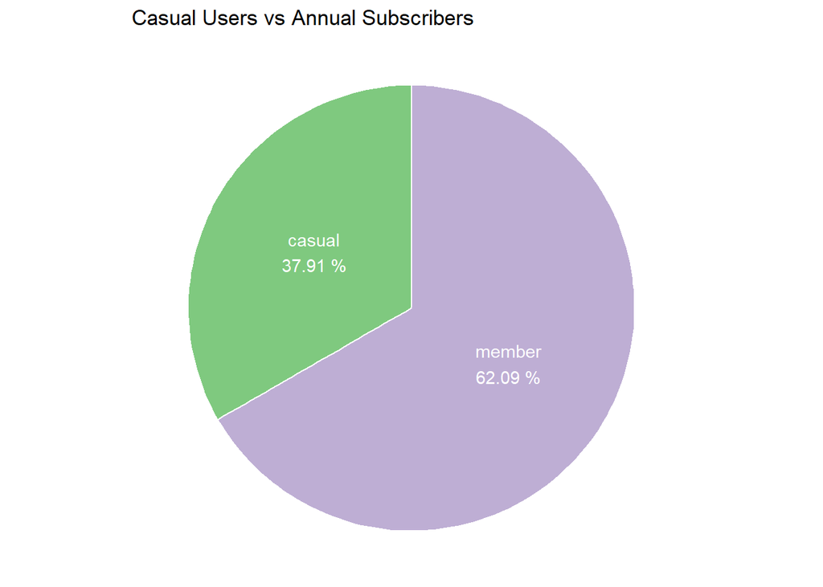

```r
fig1 <- user_type_rides %>% ggplot(aes(x = "", y = user_type, fill = user_type)) +
  geom_bar(width = 1, stat = "identity", color = "white", show.legend = FALSE) +
  coord_polar("y", start = 0) +
  geom_text(aes(label = paste(user_type, paste(pct, "%"), sep = "\n")),
            position = position_stack(vjust = 0.5), color = "white") +
  labs(title = "Casual Users vs Annual Subscribers") +
  theme_void() +
  scale_fill_brewer(palette="Accent")
```

**Figure 2. Average Ride Duration**

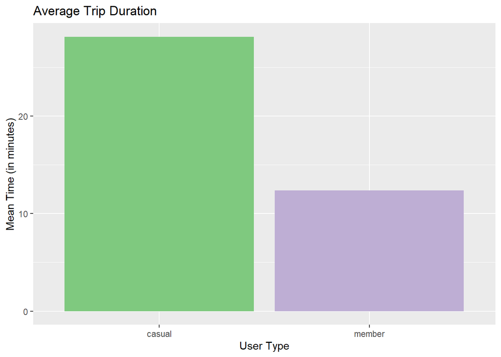

```r
user_trip_duration <- trips_clean %>%
  group_by(user_type) %>%
  summarise(mean_time = mean(trip_length_mins))

fig2 <- ggplot(user_trip_duration) +
  geom_col(mapping=aes(x=user_type,y=mean_time,fill=user_type), show.legend = FALSE)+
  labs(title = "Average Trip Duration",x="User Type",y="Mean Time (in minutes)")+
  scale_fill_brewer(palette="Accent")
```

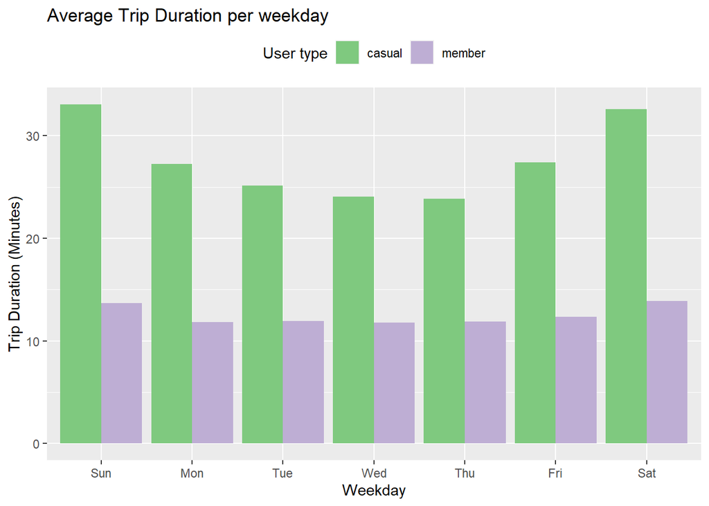

```r
fig3 <- ggplot(weekday) +
  geom_col(mapping=aes(x=started_at_day_of_week,y=mean_time,fill=user_type), show.legend = TRUE, position ="Dodge")+ scale_fill_brewer(palette="Accent") +
  labs(title = "Average Trip Duration per weekday",x="Weekday",y="Trip Duration (Minutes)", fill="User type") +
  theme(legend.position="top")
```

**Figure 4. Trips by Month**

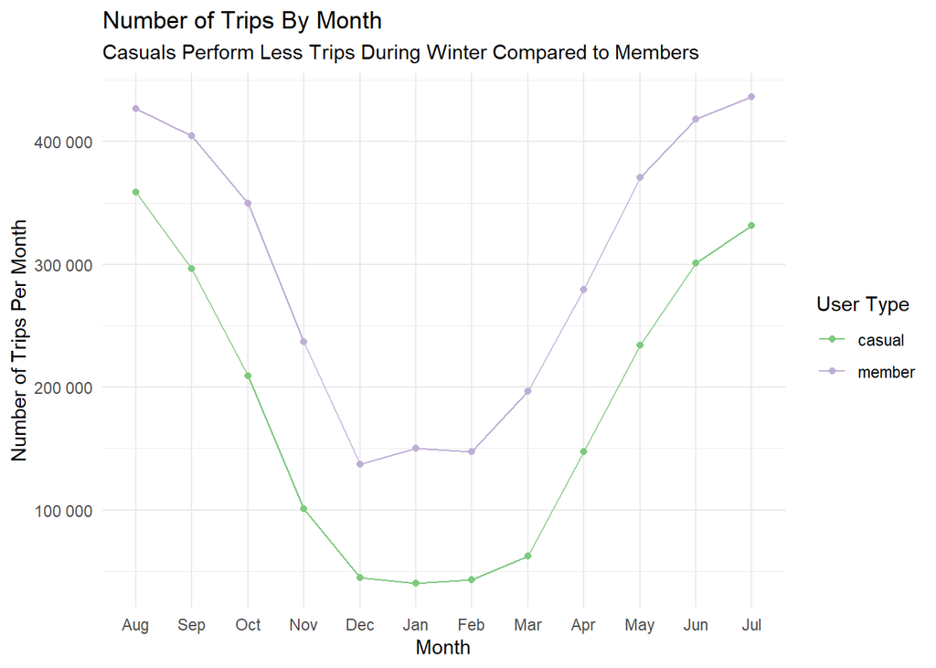

```r
fig4 <- ggplot(data = trips_by_month, aes(x = started_at_month, group = user_type, color = user_type)) +
  geom_line(aes(y = trips_by_month, group = user_type, color = user_type)) +
  geom_point(aes(y = trips_by_month)) +
  labs(
    title = "Number of Trips By Month",
    subtitle = "Casuals Perform Less Trips During Winter Compared to Members",
    x = "Month",
    y = "Number of Trips Per Month",
    color = "User Type"
  ) +
  scale_color_brewer(palette = "Accent") +
  theme_minimal() +
  scale_y_continuous(labels = scales::number_format(scale = 1))
```

**Figure 5. Bike Usage by Hour**

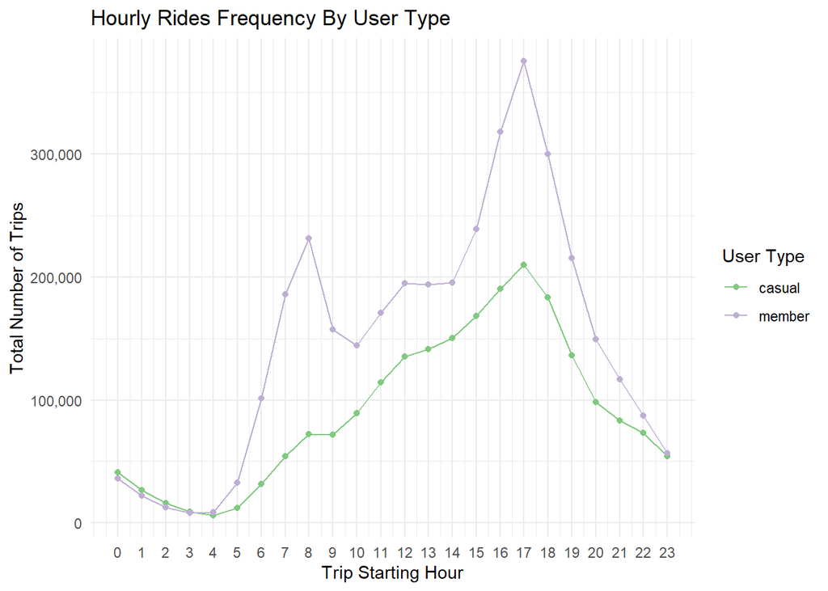

```r
fig5 <- ggplot(data=trips_by_hour, aes(x=trip_start_hour, y=n, group=user_type, color=user_type))+
  geom_line(aes(y=n))+
  geom_point(aes(y=n))+
  scale_x_continuous(breaks=c(0:23))+
  scale_y_continuous(labels = scales::comma)+
  labs(title="Hourly Rides Frequency By User Type", x="Trip Starting Hour", y="Total Number of Trips", color="User Type")+
  scale_color_brewer(palette = "Accent")+
  theme_minimal()
```

**Figure 6. Popular Stations**

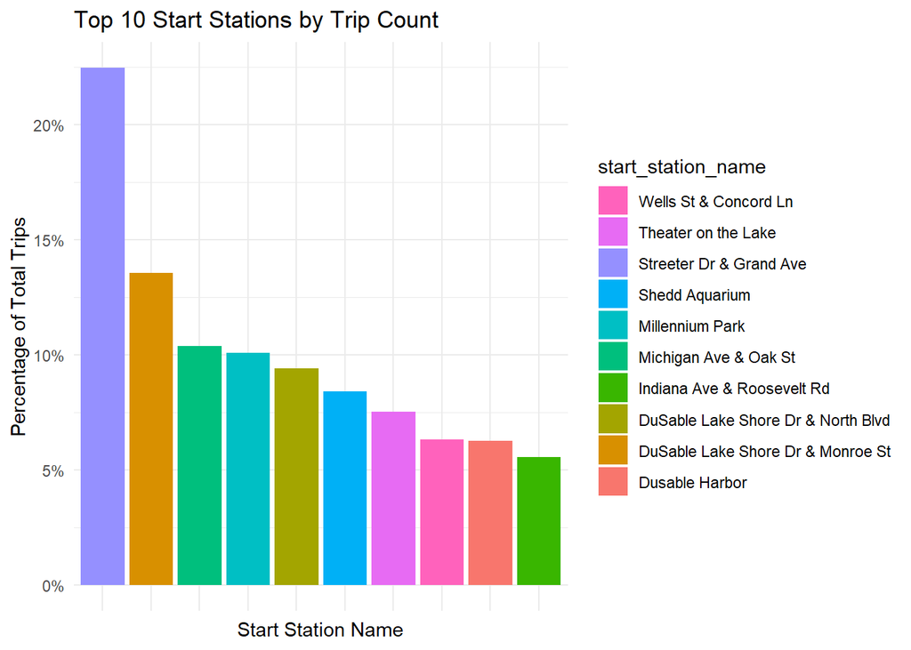

```r
fig6 <- ggplot(top_10_start_stations, aes(x = reorder(start_station_name, -trip_count), y = percentage_of_total)) +
  geom_bar(stat = "identity", aes(fill = start_station_name)) +
  labs(title = "Top 10 Start Stations by Trip Count",
       x = "Start Station Name",
       y = "Percentage of Total Trips") +
  scale_color_brewer(palette = "Accent")+
  theme_minimal() +
  theme(axis.text.x = element_blank())+
  scale_y_continuous(labels = scales::percent_format(scale = 1))+
  scale_x_discrete(labels = function(x) str_wrap(x, width = 10))+guides(fill = guide_legend(reverse = TRUE))
```

**7. Act**

With this analysis we identified different insights that the team can use to apply into their marketing strategy and increase the casual user to member rates.

**7.1 Observations**

**7.2 Recommendations**